# Cod 4T4Vn: a DFO Case Study Operating model

Technical report for Fisheries and Oceans Canada

Tom Carruthers, University of British Columbia t.carruthers@oceans.ubc.ca

# Introduction

This operating model is intended to be an exact replica of the age-based population dynamics of the MLE VPA stock assessment:

Swain, D.P., Savoie, L., Cox, S.P., and Aubry, E. 2015. Assessment of the southern Gulf of St. Lawrence Atlantic cod (Gadus morhua) stock of NAFO Div. 4T and 4Vn (November to April), March 2015. DFO Can. Sci. Advis. Sec. Res. Doc. 2015/080. xiv + 137 p.

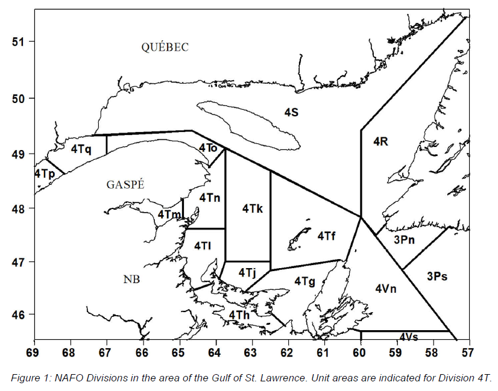

[figure not shown]

This preliminary operating model assumes full stock-mixing (essentially a single area) and has no spatial structure.

## Robustness tests

Future scenarios for maturity and growth

Alternative scenarios for future M (or MICE modelling with multiMSE)

## Improvements (operating model specification given more time)

VPA estimates were only reported from 1971 onwards despite depletion and SSB estimates starting from 1950. Where possible these inputs should match the breadth of VPA assessment estimates.

It would be desirable to obtain the bootstrapped estimates of VPA quantities for bracketting within operating model uncertainty. Once these are available, this is trivial to implement in the build script.

The real relative abundance indices should be added to the observation model to keep these historical values constant under projections and generate future values with empirically derived statistical properties.

Obtain annual effort data to empirically derive interannual variability in catchability.

# Operating Model

The OM rdata file can be downloaded from here

Download and import into R using `myOM <- readRDS('OM.rdata')`

## Species Information

**Species**: *Gadus morhua*

**Common Name**: *Atlantic cod*

**Management Agency**: DFO

**Region**: NAFO 4T4Vn (S. Gulf of St. Lawrence)

**Latitude**: 48.25

**Longitude**: -62

## OM Parameters

**OM Name**: Name of the operating model: 4T4Vn Atlantic cod

**nsim**: The number of simulations: 192

**proyears**: The number of projected years: 50

**interval**: The assessment interval - how often would you like to update the management system? 2

**pstar**: The percentile of the sample of the management recommendation for each method: 0.5

**maxF**: Maximum instantaneous fishing mortality rate that may be simulated for any given age class: 2

**reps**: Number of samples of the management recommendation for each method. Note that when this is set to 1, the mean value of the data inputs is used. 1

**Source**: A reference to a website or article from which parameters were taken to define the operating model

# Custom Parameters

The operating model makes extensive use of the cpars slot of the OM object to use the age and year specific VPA assessment estimates of:

- length-at-age by year (survey)
- weight-at-age by year (survey)
- F-at-age by year (VPA)
- maturity-at-age by year (VPA)
- Natural mortality rate (ages 2-4 and 5+) (VPA)

Future age-selectivity was assumed to follow the average pattern estimated over the last three historical years (2012-2014).

In cases where length-at-age and weight-age-age were missing, 5 year moving averages were used to fill these (mostly older age classes in recent years). In cases where there were still NAs, a 10-year moving average was applied. Weights and lengths for fish greater than age 15 were assumed to be the same as fish age 15 (highest reported value in the VPA). Future weights and lengths at age were assumed to be the same as the final historical year (2014).

Maturity was assumed to be zero for age classes 0 and 1, and 100% for age classes > 12.

Depletion was specified based on fitting a stock-recruit curve to SSB and recruitment values from the VPA, and estimating R0 from a fixed value of steepness (0.99), and the mean unfished spawners per recruit in the first nm years where nm is the age at maturity, then taking the ratio of terminal year SSB to SSB0. In this OM, depletion is around 2%.

Stock-recruitment was assumed to be Beverton-Holt and steepness and R0 were estimated from a (quick and dirty) post-hoc MLE fit to the assessment SSB and estimates of recruitment. Spawning stock biomass per recruit was calculated from the maturity and mortality at age matrices.

To calculate recruitment (age 0 N), M estimates for age classes 2-4 were assumed for age classes 0 and 1. These were only available from 1971. It follows that corresponding M age 0 (1969) and M age 1 (1970) to calculate N age 0 from N age 2 in 1971 are not available. In this case the most recent available M estimates (1971) were used.

Modelling fish from age 0 is necessary in this operating model as it may be desirable to estimate the effect of herring on age-0 cod survival.

# Stock Parameters

### Mortality and age: maxage, R0, M, Msd

**maxage**: The maximum age of individuals that is simulated. There are maxage+1 (recruitment to age-0) age classes in the storage matrices. maxage is the plus group where all age-classes > maxage are grouped, unless option switched off with OM@cpars$plusgroup=0 . Single value. Positive integer.

Specified Value(s): 12

A maximum age of 12 is used, similar to the VPA assessment.

**R0**: Initial number of unfished recruits to age-0. This number is used to scale the size of the population to match catch or data, but does not affect any of the population dynamics unless the OM has been conditioned with data. As a result, for a data-limited fishery any number can be used for R0 . In data-rich stocks R0 may be estimated as part of a stock assessment, but for data limited stocks users can choose either an arbitrary number (say, 1000) or choose a number that produces simulated catches in recent historical years that are similar to real world catch data. Single value. Positive real number.

Specified in cpars: 3565276.4, 3565276.4

Defined in cpars. This is crudely calculated by MLE estimation in the build script. Note that the correct R0 is only require in MSE if absolute quantities of TAC advice are to be used. Ie if you want to know how well a particular TAC (e.g. 10000 tonnes) may work in the future, as opposed to a scale-less MP which generally provide advice scaled to the catches of any stock.

**M**: The instantaneous rate of natural mortality. For each simulation a single value is drawn from a uniform distribution specified by the upper and lower bounds provided. Uniform distribution lower and upper bounds. Non-negative real numbers.

Specified Value(s): 1, 1

Defined in cpars. Time varying age-specific M was specified based on the values presented in the stock assessment.

**Msd**: Inter-annual variation in M expressed as a coefficient of variation of a log-normal distribution. For each simulation a single value is drawn from a uniform distribution specified by the upper and lower bounds provided. If this parameter is positive, yearly M is drawn from a log-normal distribution with a mean specified by log(M) drawn for that simulation and a standard deviation in log space specified by the value of Msd drawn for that simulation. Uniform distribution lower and upper bounds. Non-negative real numbers

Specified Value(s): 0, 0

Defined in cpars. Time varying age-specific M was specified based on the values presented in the stock assessment.

### Natural Mortality Parameters

#### Sampled Parameters

Histograms of simulations of `M`, and `Msd` parameters, with vertical colored lines indicating 3 randomly drawn values used in other plots:

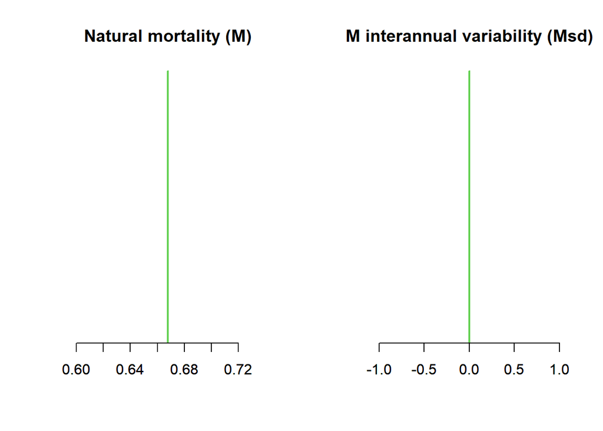

#### Time-Series

The average natural mortality rate by year for adult fish for 3 simulations. The vertical dashed line indicates the end of the historical period:

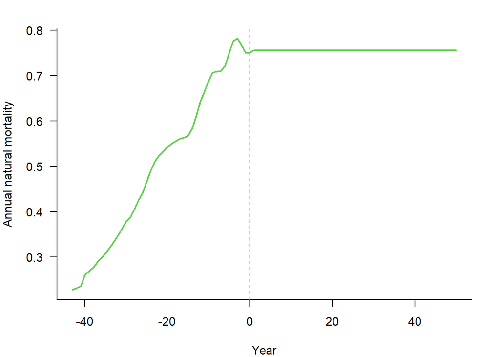

#### M-at-Age

Natural mortality-at-age for 3 simulations in the first historical year, the last historical year (i.e., current year), and the last projected year:

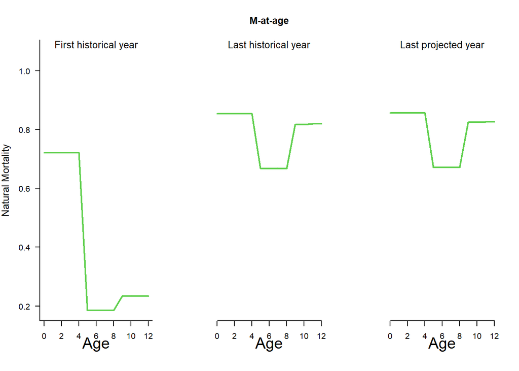

#### M-at-Length

Natural mortality-at-length for 3 simulations in the first historical year, the last historical year (i.e., current year), and the last projected year:

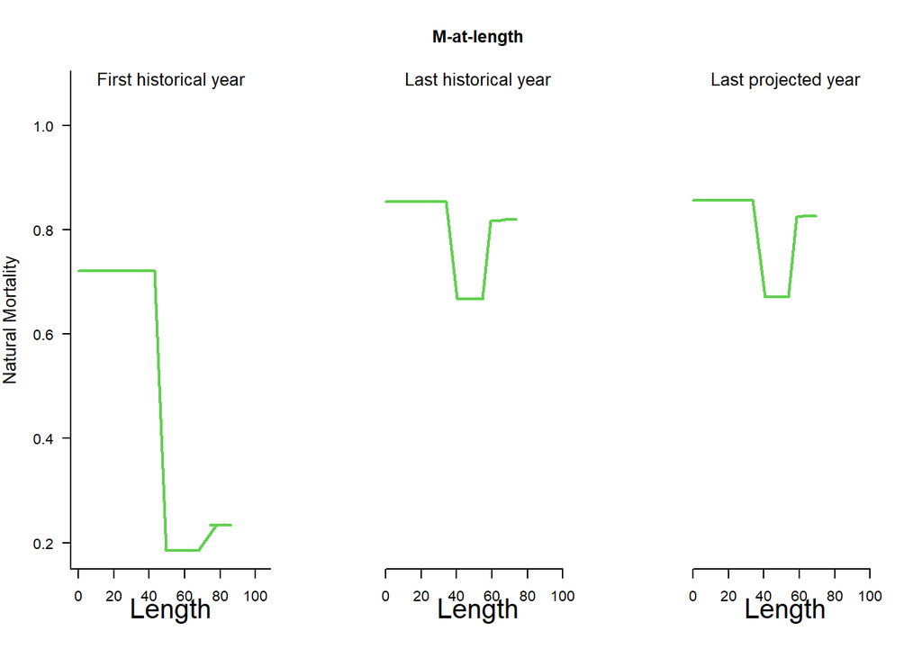

### Recruitment: h, SRrel, Perr, AC

**h**: Steepness of the stock recruit relationship. Steepness governs the proportion of unfished recruits produced when the stock is at 20% of the unfished population size. For each simulation a single value is drawn from a uniform distribution specified by the upper and lower bounds provided. This value is the same in all years of a given simulation. Uniform distribution lower and upper bounds. Values from 1/5 to 1.

Specified Value(s): 1, 1

We model an SSB-invariant recruitment relationship with steepness very close to 1.

**SRrel**: Type of stock-recruit relationship. Use 1 to select a Beverton Holt relationship, 2 to select a Ricker relationship. Single value. Integer

Specified Value(s): 1

A value of 1 represents the Beverton-Holt stock recruitment curve but this is essentially ignored and a mean recruitment with deviations model is uses instead.

**Perr**: Recruitment process error, which is defined as the standard deviation of the recruitment deviations in log space. For each simulation a single value is drawn from a uniform distribution specified by the upper and lower bounds provided. Uniform distribution lower and upper bounds. Non-negative real numbers.

Specified in cpars from the residuals from fitting a stock-recruit relationship to SSB and recruitment.

**AC**: Autocorrelation in the recruitment deviations in log space. For each simulation a single value is drawn from a uniform distribution specified by the upper and lower bounds provided, and used to add lag-1 auto-correlation to the log recruitment deviations. Uniform distribution lower and upper bounds. Non-negative real numbers.

Specified Value(s): 0.84, 0.84

Specified in cpars from the residuals from fitting a stock-recruit relationship to SSB and recruitment.

### Recruitment Parameters

#### Sampled Parameters

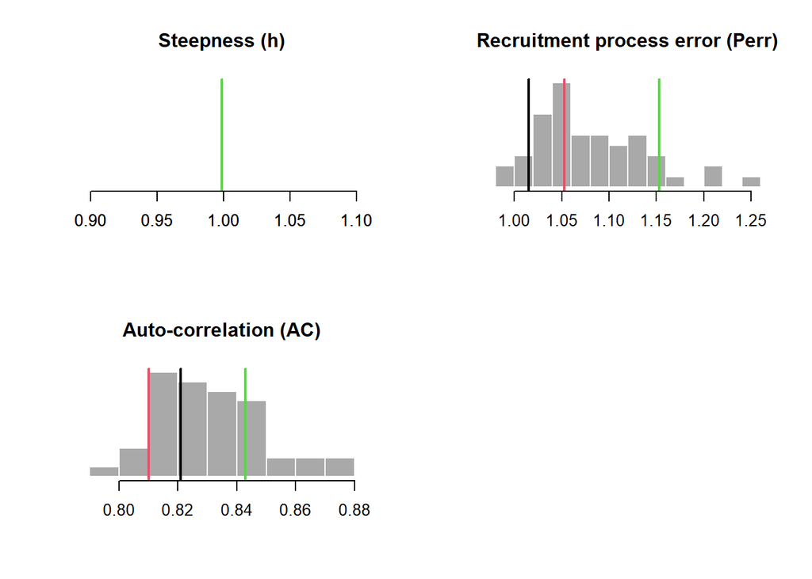

#### Time-Series

Time-series plot showing 3 samples of recruitment deviations for historical and projection years:

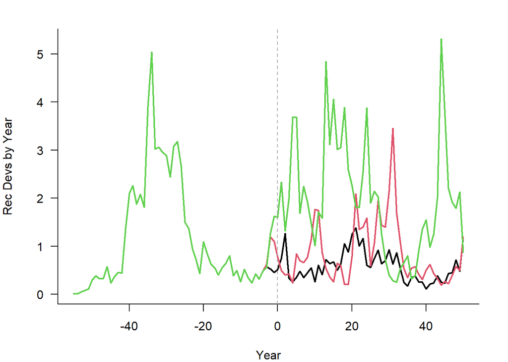

### Growth: Linf, K, t0, LenCV, Ksd, Linfsd

**Linf**: The von Bertalanffy growth parameter Linf, which specifies the average maximum size that would reached by adult fish if they lived indefinitely. For each simulation a single value is drawn from a uniform distribution specified by the upper and lower bounds provided. This value is the same in all years unless Linfsd is a positive number. Uniform distribution lower and upper bounds. Positive real numbers.

Specified in cpars: 86, 86

Back-calculated from the length at age matrices specified in cpars.

**K**: The von Bertalanffy growth parameter k, which specifies the average rate of growth. For each simulation a single value is drawn from a uniform distribution specified by the upper and lower bounds provided. This value is the same in all years unless Ksd is a positive number. Uniform distribution lower and upper bounds. Positive real numbers.

Specified in cpars: 0.122, 0.122

Back-calculated from the length at age matrices specified in cpars.

**t0**: The von Bertalanffy growth parameter t0, which specifies the theoretical age at a size 0. For each simulation a single value is drawn from a uniform distribution specified by the upper and lower bounds provided. Uniform distribution lower and upper bounds. Non-positive real numbers.

Specified in cpars: -0.25, -0.25

Back-calculated from the length at age matrices specified in cpars.

**LenCV**: The coefficient of variation (defined as the standard deviation divided by mean) of the length-at-age. For each simulation a single value is drawn from a uniform distribution specified by the upper and lower bounds provided to specify the distribution of observed length-at-age, and the CV of this distribution is constant for all age classes (i.e, standard deviation increases proportionally with the mean). Uniform distribution lower and upper bounds. Positive real numbers.

Specified in cpars: 0.1, 0.1

Back-calculated from the length at age matrices specified in cpars.

**Ksd**: Inter-annual variation in K. For each simulation a single value is drawn from a uniform distribution specified by the upper and lower bounds provided. If this parameter has a positive value, yearly K is drawn from a log-normal distribution with a mean specified by the value of K drawn for that simulation and a standard deviation (in log space) specified by the value of Ksd drawn for that simulation. Uniform distribution lower and upper bounds. Non-negative real numbers.

Specified Value(s): 0, 0

No variability in growth is assumed here.

**Linfsd**: Inter-annual variation in Linf. For each simulation a single value is drawn from a uniform distribution specified by the upper and lower bounds provided. If this parameter has a positive value, yearly Linf is drawn from a log-normal distribution with a mean specified by the value of Linf drawn for that simulation and a standard deviation (in log space) specified by the value of Linfsd drawn for that simulation. Uniform distribution lower and upper bounds. Non-negative real numbers.

Specified Value(s): 0, 0

No variability in growth is assumed here.

### Growth Parameters

#### Sampled Parameters

Histograms of simulations of von Bertalanffy growth parameters `Linf`, `K`, and `t0`, and inter-annual variability in Linf and K (`Linfsd` and `Ksd`), with vertical colored lines indicating 3 randomly drawn values used in other plots:

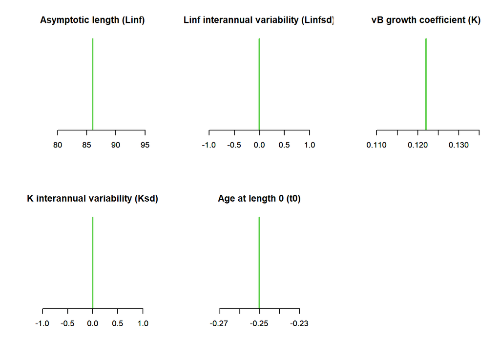

#### Time-Series

The Linf and K parameters in each year for 3 simulations. The vertical dashed line indicates the end of the historical period:

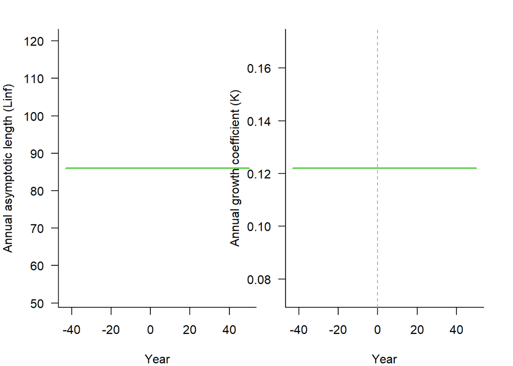

#### Growth Curves

Sampled length-at-age curves for 3 simulations in the first historical year, the last historical year, and the last projection year.

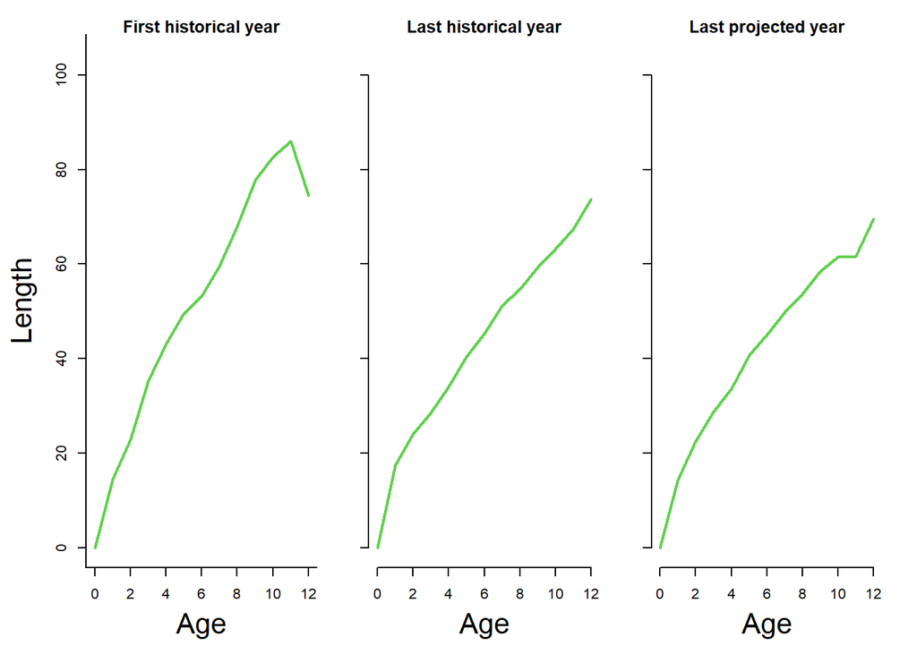

### Maturity: L50, L50_95

**L50**: Length at 50% maturity. For each simulation a single value is drawn from a uniform distribution specified by the upper and lower bounds provided. The L50 and L50_95 parameters are converted to ages using the growth parameters provided and used to construct a logistic curve to determine the proportion of the population that is mature in each age class. Uniform distribution lower and upper bounds. Positive real numbers.

Specified Value(s): 1, 1

Back-calculated from the maturity at age matrices specified in cpars.

**L50_95**: Difference in lengths between 50% and 95% maturity. For each simulation a single value is drawn from a uniform distribution specified by the upper and lower bounds provided. The value drawn is then added to the length at 50% maturity to determine the length at 95% maturity. This parameterization is used instead of specifying the size at 95 percent maturity to avoid situations where the value drawn for the size at 95% maturity is smaller than that at 50% maturity. The L50 and L50_95 parameters are converted to ages using the growth parameters provided and used to construct a logistic curve to determine the proportion of the population that is mature in each age class. Uniform distribution lower and upper bounds. Positive real numbers.

Specified Value(s): 1, 1

Back-calculated from the maturity at age matrices specified in cpars.

### Maturity Parameters

#### Sampled Parameters

Histograms of simulations of `L50` (length at 50% maturity), and `L95` (length at 95% maturity), with vertical colored lines indicating 3 randomly drawn values used in other plots:

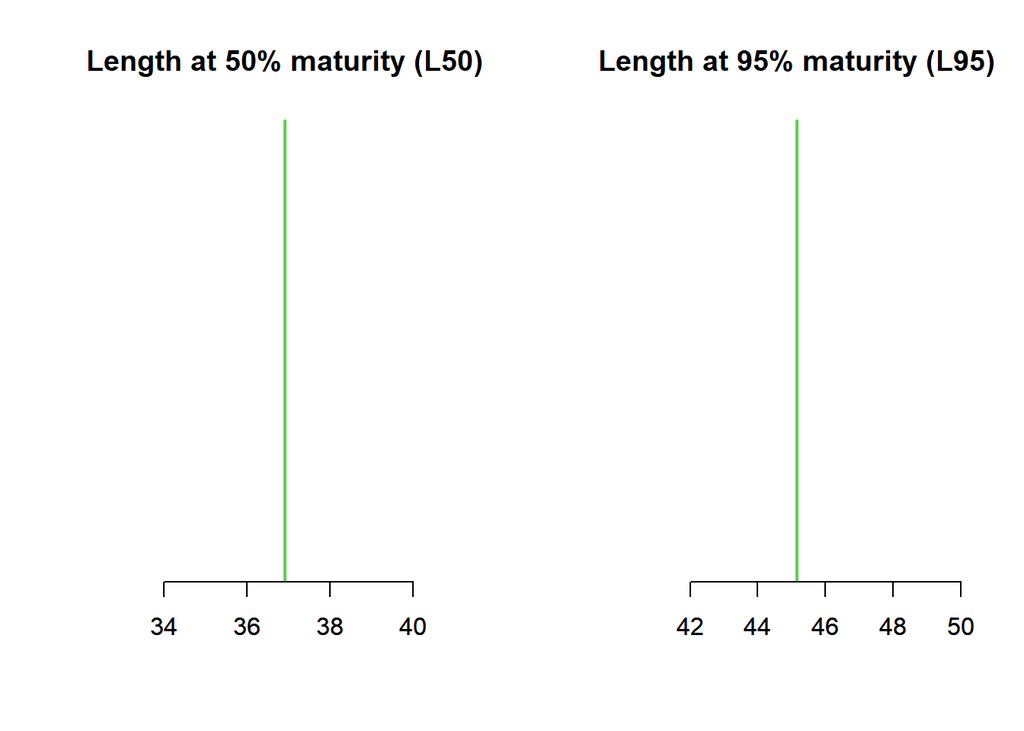

#### Maturity at Age and Length

Maturity-at-age and -length for 3 simulations in the first historical year, the last historical year (i.e., current year), and the last projected year:

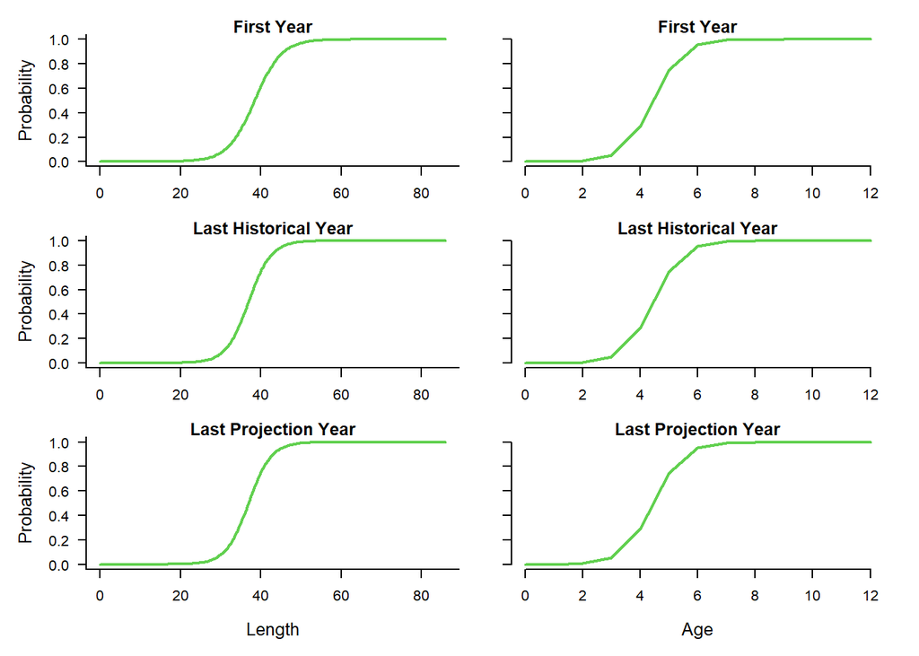

### Stock depletion and Discard Mortality: D, Fdisc

**D**: Estimated current level of stock depletion, which is defined as the current spawning stock biomass divided by the unfished spawning stock biomass. For each simulation a single value is drawn from a uniform distribution specified by the upper and lower bounds provided. This parameter is used during model initialization to select a series of yearly historical recruitment values and fishing mortality rates that, based on the information provided, could have resulted in the specified depletion level in the simulated last historical year. Uniform distribution lower and upper bounds. Positive real numbers (typically < 1)

Specified in cpars: 0.021, 0.021

An incredibly narrow range of depletions can be obtained by varying fishing from almost taking all vulnerable fish to zero fish. In this case SSB(2014) / SSB0 was around 2%. Stock depletion in 2014 is entirely driven by non-fishing related factors such as changes in survival rate, maturity, weight and recruitment.

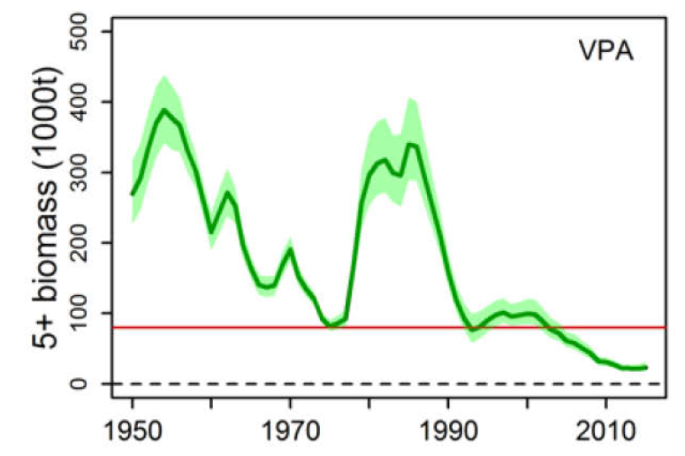

2014 SSB trend VPA

**Fdisc**: The instantaneous discard mortality rate the stock experiences when fished using the gear type specified in the corresponding fleet object and discarded. For each simulation a single value is drawn from a uniform distribution specified by the upper and lower bounds provided. Uniform distribution lower and upper bounds. Non-negative real numbers.

Specified Value(s): 0, 0

### Depletion and Discard Mortality

#### Sampled Parameters

Histograms of simulations of depletion (spawning biomass in the last historical year over average unfished spawning biomass; `D`) and the fraction of discarded fish that are killed by fishing mortality (`Fdisc`), with vertical colored lines indicating 3 randomly drawn values.

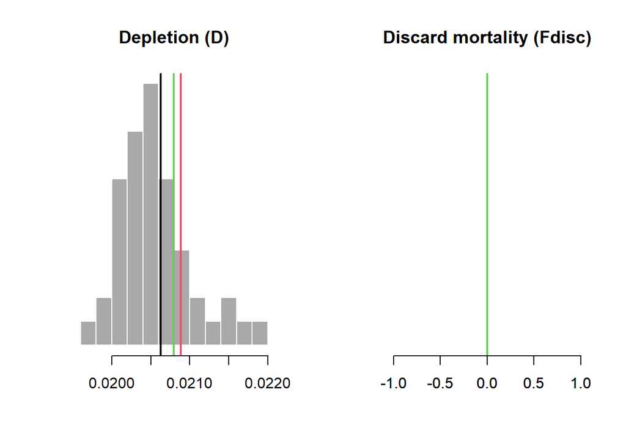